# CMS Synthetic Data (DE-SynPUF) — Full Sample 1 Pull, Cleaning & Validation

## 4. Beneficiary Summary Files

```r
bene_2008_raw <- read_csv("../Data/Extracted/DE1_0_2008_Beneficiary_Summary_File_Sample_1.csv",
                           col_types = cols(.default = "c"))
bene_2009_raw <- read_csv("../Data/Extracted/DE1_0_2009_Beneficiary_Summary_File_Sample_1.csv",
                           col_types = cols(.default = "c"))
bene_2010_raw <- read_csv("../Data/Extracted/DE1_0_2010_Beneficiary_Summary_File_Sample_1.csv",
                           col_types = cols(.default = "c"))

validate_count("Beneficiary Summary 2008", CMS_SAMPLE1$bene_2008, nrow(bene_2008_raw))
```

Validation vs. CMS Data User’s Guide, Sample 1 (running)

| file | cms_documented | actual | match | diff |
| --- | --- | --- | --- | --- |
| Beneficiary Summary 2008 | 116,352 | 116,352 | TRUE | 0 |

```r
validate_count("Beneficiary Summary 2009", CMS_SAMPLE1$bene_2009, nrow(bene_2009_raw))
```

Validation vs. CMS Data User’s Guide, Sample 1 (running)

| file | cms_documented | actual | match | diff |
| --- | --- | --- | --- | --- |
| Beneficiary Summary 2008 | 116,352 | 116,352 | TRUE | 0 |
| Beneficiary Summary 2009 | 114,538 | 114,538 | TRUE | 0 |

```r
validate_count("Beneficiary Summary 2010", CMS_SAMPLE1$bene_2010, nrow(bene_2010_raw))
```

Validation vs. CMS Data User’s Guide, Sample 1 (running)

| file | cms_documented | actual | match | diff |
| --- | --- | --- | --- | --- |
| Beneficiary Summary 2008 | 116,352 | 116,352 | TRUE | 0 |
| Beneficiary Summary 2009 | 114,538 | 114,538 | TRUE | 0 |
| Beneficiary Summary 2010 | 112,754 | 112,754 | TRUE | 0 |

All three years read in as character to start — the files mix dates, flags coded `1`/`2`, and dollar amounts, so typing happens explicitly below rather than relying on `readr`’s guesses. None of the 32 raw columns are fully empty in any of the three years, so the only column *dropped* here is `BENE_COUNTY_CD` (by request, not because it’s empty) — everything else is recoded, renamed, and cast.

```r
clean_beneficiary <- function(df, year) {
  df %>%
    clean_names() %>%
    select(-bene_county_cd) %>%
    mutate(
      bene_birth_dt = ymd(bene_birth_dt),
      bene_death_dt = ymd(bene_death_dt),
      across(
        c(sp_alzhdmta, sp_chf, sp_chrnkidn, sp_cncr, sp_copd, sp_depressn,
          sp_diabetes, sp_ischmcht, sp_osteoprs, sp_ra_oa, sp_strketia),
        ~ .x == "1"
      ),
      # number of the 11 CMS-flagged chronic conditions this beneficiary has
      # in this year — a simple row-sum now that the flags are boolean
      chronic_condition_count = rowSums(across(c(
        sp_alzhdmta, sp_chf, sp_chrnkidn, sp_cncr, sp_copd, sp_depressn,
        sp_diabetes, sp_ischmcht, sp_osteoprs, sp_ra_oa, sp_strketia
      ))),
      bene_sex_ident_cd = recode(bene_sex_ident_cd, "1" = "male", "2" = "female"),
      bene_esrd_ind = bene_esrd_ind == "Y",
      bene_race_cd = unname(RACE_CODES[bene_race_cd]),
      sp_state_code = unname(STATE_CODES[sp_state_code]),
      across(
        c(medreimb_ip, benres_ip, pppymt_ip,
          medreimb_op, benres_op, pppymt_op,
          medreimb_car, benres_car, pppymt_car),
        as.numeric
      ),
      # total annual amount = Medicare-paid + primary-payer-paid + beneficiary
      # responsibility, summed across all three claim types (IP/OP/Carrier) —
      # the same three-part total the claims files carry, rolled up to a
      # single beneficiary-year figure
      total_annual_amt = medreimb_ip + benres_ip + pppymt_ip +
        medreimb_op + benres_op + pppymt_op +
        medreimb_car + benres_car + pppymt_car,
      reference_year = year
    ) %>%
    rename(
      beneficiary_id = desynpuf_id,
      birth_date = bene_birth_dt,
      death_date = bene_death_dt,
      sex = bene_sex_ident_cd,
      race = bene_race_cd,
      esrd_indicator = bene_esrd_ind,
      state = sp_state_code,
      part_a_coverage_months = bene_hi_cvrage_tot_mons,
      part_b_coverage_months = bene_smi_cvrage_tot_mons,
      hmo_coverage_months = bene_hmo_cvrage_tot_mons,
      part_d_coverage_months = plan_cvrg_mos_num,
      chronic_alzheimer = sp_alzhdmta,
      chronic_heart_failure = sp_chf,
      chronic_kidney_disease = sp_chrnkidn,
      chronic_cancer = sp_cncr,
      chronic_copd = sp_copd,
      chronic_depression = sp_depressn,
      chronic_diabetes = sp_diabetes,
      chronic_ischemic_heart_disease = sp_ischmcht,
      chronic_osteoporosis = sp_osteoprs,
      chronic_rheumatoid_or_osteoarthritis = sp_ra_oa,
      chronic_stroke_tia = sp_strketia,
      annual_medicare_reimb_ip = medreimb_ip,
      annual_beneficiary_resp_ip = benres_ip,
      annual_primary_payer_reimb_ip = pppymt_ip,
      annual_medicare_reimb_op = medreimb_op,
      annual_beneficiary_resp_op = benres_op,
      annual_primary_payer_reimb_op = pppymt_op,
      annual_medicare_reimb_car = medreimb_car,
      annual_beneficiary_resp_car = benres_car,
      annual_primary_payer_reimb_car = pppymt_car
    )
}

bene_2008 <- clean_beneficiary(bene_2008_raw, 2008)
bene_2009 <- clean_beneficiary(bene_2009_raw, 2009)
bene_2010 <- clean_beneficiary(bene_2010_raw, 2010)

rows_each <- nrow(bene_2008) + nrow(bene_2009) + nrow(bene_2010)
beneficiary_all <- bind_rows(bene_2008, bene_2009, bene_2010) %>%
  relocate(reference_year, .after = beneficiary_id)

log_step("beneficiary", "drop county; recode race/state; rename all columns; add total_annual_amt + chronic_condition_count; row-bind years",
         rows_each, nrow(beneficiary_all),
         ncol(bene_2008_raw), ncol(beneficiary_all),
         "dropped bene_county_cd (1 col); added reference_year + total_annual_amt + chronic_condition_count (3 cols) — net +2 columns vs. raw")
```

Pipeline ledger (running)

| dataset | step | rows_before | rows_after | cols_before | cols_after | note |
| --- | --- | --- | --- | --- | --- | --- |
| beneficiary | drop county; recode race/state; rename all columns; add total_annual_amt + chronic_condition_count; row-bind years | 343,644 | 343,644 | 32 | 34 | dropped bene_county_cd (1 col); added reference_year + total_annual_amt + chronic_condition_count (3 cols) — net +2 columns vs. raw |

### Sanity checks

```r
beneficiary_all %>% count(reference_year, name = "n_beneficiaries") %>% knitr::kable()
```

| reference_year | n_beneficiaries |
| --- | --- |
| 2008 | 116352 |
| 2009 | 114538 |
| 2010 | 112754 |

```r
dup_check <- beneficiary_all %>% count(beneficiary_id, reference_year) %>% filter(n > 1) %>% nrow()
cat("Duplicate (id, year) pairs:", dup_check, "\n")
```

```
## Duplicate (id, year) pairs: 0
```

```r
beneficiary_all %>% count(race, name = "n") %>% knitr::kable(caption = "Race, recoded")
```

Race, recoded

| race | n |
| --- | --- |
| Black | 36459 |
| Hispanic | 8080 |
| Other | 14591 |
| White | 284514 |

```r
beneficiary_all %>% count(state, name = "n") %>% arrange(desc(n)) %>% head(5) %>%
  knitr::kable(caption = "State, recoded (top 5)")
```

State, recoded (top 5)

| state | n |
| --- | --- |
| CA | 30217 |
| FL | 22888 |
| TX | 19833 |
| NY | 19258 |
| PA | 15358 |

```r
beneficiary_all %>%
  summarise(mean_total_annual_amt = mean(total_annual_amt, na.rm = TRUE),
            median_total_annual_amt = median(total_annual_amt, na.rm = TRUE),
            max_total_annual_amt = max(total_annual_amt, na.rm = TRUE)) %>%
  knitr::kable(caption = "total_annual_amt = Medicare-paid + primary-payer-paid + beneficiary responsibility, summed across IP/OP/Carrier")
```

total_annual_amt = Medicare-paid + primary-payer-paid + beneficiary responsibility, summed across IP/OP/Carrier

| mean_total_annual_amt | median_total_annual_amt | max_total_annual_amt |
| --- | --- | --- |
| 4449.089 | 1440 | 223282 |

```r
beneficiary_all %>% count(chronic_condition_count, name = "n_beneficiary_years") %>%
  knitr::kable(caption = "chronic_condition_count distribution (0-11 conditions)")
```

chronic_condition_count distribution (0-11 conditions)

| chronic_condition_count | n_beneficiary_years |
| --- | --- |
| 0 | 125983 |
| 1 | 44306 |
| 2 | 41353 |
| 3 | 36871 |
| 4 | 31253 |
| 5 | 24639 |
| 6 | 17785 |
| 7 | 11688 |
| 8 | 6366 |
| 9 | 2613 |
| 10 | 701 |
| 11 | 86 |

## 5. Inpatient Claims

```r
ip_raw <- fread("../Data/Extracted/DE1_0_2008_to_2010_Inpatient_Claims_Sample_1.csv", colClasses = "character")
validate_count("Inpatient Claims (2008-2010)", CMS_SAMPLE1$ip, nrow(ip_raw))
```

Validation vs. CMS Data User’s Guide, Sample 1 (running)

| file | cms_documented | actual | match | diff |
| --- | --- | --- | --- | --- |
| Beneficiary Summary 2008 | 116,352 | 116,352 | TRUE | 0 |
| Beneficiary Summary 2009 | 114,538 | 114,538 | TRUE | 0 |
| Beneficiary Summary 2010 | 112,754 | 112,754 | TRUE | 0 |
| Inpatient Claims (2008-2010) | 66,773 | 66,773 | TRUE | 0 |

```r
ip_na_rate <- sapply(names(ip_raw), function(cn) mean(is.na(ip_raw[[cn]]) | ip_raw[[cn]] == ""))
ip_empty_cols <- names(ip_na_rate)[ip_na_rate == 1]
cat("Fully-empty columns in this sample (", length(ip_empty_cols), "of", ncol(ip_raw), "):\n")
```

```
## Fully-empty columns in this sample ( 45 of 81 ):
```

```r
cat(paste(ip_empty_cols, collapse = ", "), "\n")
```

```
## HCPCS_CD_1, HCPCS_CD_2, HCPCS_CD_3, HCPCS_CD_4, HCPCS_CD_5, HCPCS_CD_6, HCPCS_CD_7, HCPCS_CD_8, HCPCS_CD_9, HCPCS_CD_10, HCPCS_CD_11, HCPCS_CD_12, HCPCS_CD_13, HCPCS_CD_14, HCPCS_CD_15, HCPCS_CD_16, HCPCS_CD_17, HCPCS_CD_18, HCPCS_CD_19, HCPCS_CD_20, HCPCS_CD_21, HCPCS_CD_22, HCPCS_CD_23, HCPCS_C…
```

Every `HCPCS_CD_*` slot (all 45 of them) is 100% empty in this sample — inpatient claims are DRG-priced and don’t carry line-level HCPCS codes the way outpatient/carrier claims do, so this isn’t a data problem, it’s expected structure. They’re dropped. Everything else is renamed to a descriptive name (via the Codebook’s labels) and cast; four columns that were previously left as raw strings — three beneficiary liability columns (`beneficiary_deductible_amt`, `beneficiary_part_a_coinsurance_amt`, `beneficiary_blood_deductible_amt`) and `pass_through_per_diem_amt` — are now cast to numeric too, since `total_claim_amt` below and the Section 14 reconciliation both need to sum them.

```r
ip_cols_before <- ncol(ip_raw)
ip_reduced <- ip_raw[, setdiff(names(ip_raw), ip_empty_cols), with = FALSE]

inpatient_clean <- ip_reduced %>%
  as_tibble() %>%
  clean_names() %>%
  mutate(
    clm_from_dt = ymd(clm_from_dt),
    clm_thru_dt = ymd(clm_thru_dt),
    clm_admsn_dt = ymd(clm_admsn_dt),
    nch_bene_dschrg_dt = ymd(nch_bene_dschrg_dt),
    clm_pmt_amt = as.numeric(clm_pmt_amt),
    nch_prmry_pyr_clm_pd_amt = as.numeric(nch_prmry_pyr_clm_pd_amt),
    nch_bene_ip_ddctbl_amt = as.numeric(nch_bene_ip_ddctbl_amt),
    nch_bene_pta_coinsrnc_lblty_am = as.numeric(nch_bene_pta_coinsrnc_lblty_am),
    nch_bene_blood_ddctbl_lblty_am = as.numeric(nch_bene_blood_ddctbl_lblty_am),
    clm_pass_thru_per_diem_amt = as.numeric(clm_pass_thru_per_diem_amt),
    clm_utlztn_day_cnt = as.integer(clm_utlztn_day_cnt),
    length_of_stay = as.integer(nch_bene_dschrg_dt - clm_admsn_dt),
    # total amount = Medicare-paid + primary-payer-paid + beneficiary liability
    # (deductible + Part A coinsurance + blood deductible)
    total_claim_amt = clm_pmt_amt + nch_prmry_pyr_clm_pd_amt +
      nch_bene_ip_ddctbl_amt + nch_bene_pta_coinsrnc_lblty_am + nch_bene_blood_ddctbl_lblty_am
  ) %>%
  rename(
    beneficiary_id = desynpuf_id,
    claim_id = clm_id,
    claim_line_segment = segment,
    claim_start_date = clm_from_dt,
    claim_end_date = clm_thru_dt,
    provider_institution_id = prvdr_num,
    medicare_payment_amt = clm_pmt_amt,
    primary_payer_paid_amt = nch_prmry_pyr_clm_pd_amt,
    attending_physician_npi = at_physn_npi,
    operating_physician_npi = op_physn_npi,
    other_physician_npi = ot_physn_npi,
    admission_date = clm_admsn_dt,
    admitting_diagnosis_code = admtng_icd9_dgns_cd,
    pass_through_per_diem_amt = clm_pass_thru_per_diem_amt,
    beneficiary_deductible_amt = nch_bene_ip_ddctbl_amt,
    beneficiary_part_a_coinsurance_amt = nch_bene_pta_coinsrnc_lblty_am,
    beneficiary_blood_deductible_amt = nch_bene_blood_ddctbl_lblty_am,
    utilization_day_count = clm_utlztn_day_cnt,
    discharge_date = nch_bene_dschrg_dt,
    drg_code = clm_drg_cd
  ) %>%
  rename_with(~ str_replace(., "^icd9_dgns_cd_", "diagnosis_code_"), starts_with("icd9_dgns_cd_")) %>%
  rename_with(~ str_replace(., "^icd9_prcdr_cd_", "procedure_code_"), starts_with("icd9_prcdr_cd_"))

log_step("inpatient", "drop empty HCPCS cols; rename; add total_claim_amt",
         nrow(ip_raw), nrow(inpatient_clean), ip_cols_before, ncol(inpatient_clean),
         paste0("dropped ", length(ip_empty_cols), " HCPCS_CD_* (100% empty); added length_of_stay + total_claim_amt (2 cols)"))
```

Pipeline ledger (running)

| dataset | step | rows_before | rows_after | cols_before | cols_after | note |
| --- | --- | --- | --- | --- | --- | --- |
| beneficiary | drop county; recode race/state; rename all columns; add total_annual_amt + chronic_condition_count; row-bind years | 343,644 | 343,644 | 32 | 34 | dropped bene_county_cd (1 col); added reference_year + total_annual_amt + chronic_condition_count (3 cols) — net +2 columns vs. raw |
| inpatient | drop empty HCPCS cols; rename; add total_claim_amt | 66,773 | 66,773 | 81 | 38 | dropped 45 HCPCS_CD_* (100% empty); added length_of_stay + total_claim_amt (2 cols) |

```r
inpatient_clean %>%
  summarise(n_claims = n(), n_beneficiaries = n_distinct(beneficiary_id),
            total_medicare_paid = sum(medicare_payment_amt, na.rm = TRUE),
            total_claim_amt = sum(total_claim_amt, na.rm = TRUE),
            median_length_of_stay = median(length_of_stay, na.rm = TRUE)) %>%
  knitr::kable()
```

| n_claims | n_beneficiaries | total_medicare_paid | total_claim_amt | median_length_of_stay |
| --- | --- | --- | --- | --- |
| 66773 | 37780 | 639260180 | 712919366 | 4 |

### Referential check against beneficiaries

```r
ip_orphans <- inpatient_clean %>% distinct(beneficiary_id) %>% anti_join(beneficiary_all, by = "beneficiary_id") %>% nrow()
cat("Inpatient beneficiaries with no match in the beneficiary file:", ip_orphans, "\n")
```

```
## Inpatient beneficiaries with no match in the beneficiary file: 0
```

## 6. Outpatient Claims

```r
op_raw <- fread("../Data/Extracted/DE1_0_2008_to_2010_Outpatient_Claims_Sample_1.csv", colClasses = "character")
validate_count("Outpatient Claims (2008-2010)", CMS_SAMPLE1$op, nrow(op_raw))
```

Validation vs. CMS Data User’s Guide, Sample 1 (running)

| file | cms_documented | actual | match | diff |
| --- | --- | --- | --- | --- |
| Beneficiary Summary 2008 | 116,352 | 116,352 | TRUE | 0 |
| Beneficiary Summary 2009 | 114,538 | 114,538 | TRUE | 0 |
| Beneficiary Summary 2010 | 112,754 | 112,754 | TRUE | 0 |
| Inpatient Claims (2008-2010) | 66,773 | 66,773 | TRUE | 0 |
| Outpatient Claims (2008-2010) | 790,790 | 790,790 | TRUE | 0 |

```r
op_na_rate <- sapply(names(op_raw), function(cn) mean(is.na(op_raw[[cn]]) | op_raw[[cn]] == ""))
op_empty_cols <- names(op_na_rate)[op_na_rate == 1]
cat("Fully-empty columns (", length(op_empty_cols), "of", ncol(op_raw), "):", paste(op_empty_cols, collapse=", "), "\n")
```

```
## Fully-empty columns ( 1 of 76 ): HCPCS_CD_45
```

```r
op_cols_before <- ncol(op_raw)
op_reduced <- op_raw[, setdiff(names(op_raw), op_empty_cols), with = FALSE]

outpatient_clean <- op_reduced %>%
  as_tibble() %>%
  clean_names() %>%
  mutate(
    clm_from_dt = ymd(clm_from_dt),
    clm_thru_dt = ymd(clm_thru_dt),
    clm_pmt_amt = as.numeric(clm_pmt_amt),
    nch_prmry_pyr_clm_pd_amt = as.numeric(nch_prmry_pyr_clm_pd_amt),
    nch_bene_blood_ddctbl_lblty_am = as.numeric(nch_bene_blood_ddctbl_lblty_am),
    nch_bene_ptb_ddctbl_amt = as.numeric(nch_bene_ptb_ddctbl_amt),
    nch_bene_ptb_coinsrnc_amt = as.numeric(nch_bene_ptb_coinsrnc_amt),
    # total amount = Medicare-paid + primary-payer-paid + beneficiary liability
    # (blood deductible + Part B deductible + Part B coinsurance)
    total_claim_amt = clm_pmt_amt + nch_prmry_pyr_clm_pd_amt +
      nch_bene_blood_ddctbl_lblty_am + nch_bene_ptb_ddctbl_amt + nch_bene_ptb_coinsrnc_amt
  ) %>%
  rename(
    beneficiary_id = desynpuf_id,
    claim_id = clm_id,
    claim_line_segment = segment,
    claim_start_date = clm_from_dt,
    claim_end_date = clm_thru_dt,
    provider_institution_id = prvdr_num,
    medicare_payment_amt = clm_pmt_amt,
    primary_payer_paid_amt = nch_prmry_pyr_clm_pd_amt,
    attending_physician_npi = at_physn_npi,
    operating_physician_npi = op_physn_npi,
    other_physician_npi = ot_physn_npi,
    beneficiary_blood_deductible_amt = nch_bene_blood_ddctbl_lblty_am,
    beneficiary_part_b_deductible_amt = nch_bene_ptb_ddctbl_amt,
    beneficiary_part_b_coinsurance_amt = nch_bene_ptb_coinsrnc_amt,
    admitting_diagnosis_code = admtng_icd9_dgns_cd
  ) %>%
  rename_with(~ str_replace(., "^icd9_dgns_cd_", "diagnosis_code_"), starts_with("icd9_dgns_cd_")) %>%
  rename_with(~ str_replace(., "^icd9_prcdr_cd_", "procedure_code_"), starts_with("icd9_prcdr_cd_")) %>%
  rename_with(~ str_replace(., "^hcpcs_cd_", "procedure_hcpcs_code_"), starts_with("hcpcs_cd_"))

log_step("outpatient", "drop 1 empty HCPCS col; rename; add total_claim_amt",
         nrow(op_raw), nrow(outpatient_clean), op_cols_before, ncol(outpatient_clean),
         paste("dropped:", paste(op_empty_cols, collapse=", "), "; added total_claim_amt (1 col)"))
```

Pipeline ledger (running)

| dataset | step | rows_before | rows_after | cols_before | cols_after | note |
| --- | --- | --- | --- | --- | --- | --- |
| beneficiary | drop county; recode race/state; rename all columns; add total_annual_amt + chronic_condition_count; row-bind years | 343,644 | 343,644 | 32 | 34 | dropped bene_county_cd (1 col); added reference_year + total_annual_amt + chronic_condition_count (3 cols) — net +2 columns vs. raw |
| inpatient | drop empty HCPCS cols; rename; add total_claim_amt | 66,773 | 66,773 | 81 | 38 | dropped 45 HCPCS_CD_* (100% empty); added length_of_stay + total_claim_amt (2 cols) |
| outpatient | drop 1 empty HCPCS col; rename; add total_claim_amt | 790,790 | 790,790 | 76 | 76 | dropped: HCPCS_CD_45 ; added total_claim_amt (1 col) |

```r
rm(op_raw, op_reduced); gc(verbose = FALSE)
```

```
##             used  (Mb) gc trigger   (Mb)  max used   (Mb)
## Ncells   2592379 138.5    3851930  205.8   3851930  205.8
## Vcells 105772890 807.0  286879194 2188.8 284426456 2170.1
```

### Referential check against beneficiaries

```r
op_orphans <- outpatient_clean %>% distinct(beneficiary_id) %>% anti_join(beneficiary_all, by = "beneficiary_id") %>% nrow()
cat("Outpatient beneficiaries with no match in the beneficiary file:", op_orphans, "\n")
```

```
## Outpatient beneficiaries with no match in the beneficiary file: 0
```

## 7. Carrier Claims (Segments A + B)

Carrier claims are the largest file type by far: 142 columns, ~2.37M rows *per segment* (CMS split each subsample into A/B purely for file-size reasons — it’s one logical file). Each segment is ~1.2GB as CSV, and this machine has ~5GB of free RAM, so both segments are never held in memory at once: each is read, reduced to a claim-level summary, and discarded (`rm()` + `gc()`) before the next one loads.

142 columns is mostly *repetition*: up to 13 service lines per claim, each with its own physician NPI, tax number, HCPCS code, and dollar amounts for Medicare payment, primary-payer payment, Part B deductible, coinsurance, and allowed charge — plus a processing-indicator code and a line-level diagnosis code. Rather than rename those 1:1, the cleaning step collapses them to a per-claim summary: line count, primary HCPCS code, and totals across *all three* payer components CMS tracks at the line level (Medicare paid, primary payer paid, and beneficiary liability). Per-line physician NPIs, tax numbers, processing-indicator codes, and line-level diagnosis pointers are still dropped — those don’t roll up into a meaningful per-claim total.

```r
summarize_carrier <- function(dt) {
  hcpcs_cols      <- grep("^HCPCS_CD_", names(dt), value = TRUE)
  nch_cols        <- grep("^LINE_NCH_PMT_AMT_", names(dt), value = TRUE)
  coins_cols      <- grep("^LINE_COINSRNC_AMT_", names(dt), value = TRUE)
  alowd_cols      <- grep("^LINE_ALOWD_CHRG_AMT_", names(dt), value = TRUE)
  ptb_ddctbl_cols <- grep("^LINE_BENE_PTB_DDCTBL_AMT_", names(dt), value = TRUE)
  prmry_pyr_cols  <- grep("^LINE_BENE_PRMRY_PYR_PD_AMT_", names(dt), value = TRUE)
  dgns_cols       <- grep("^ICD9_DGNS_CD_", names(dt), value = TRUE)

  sum_cols <- function(cols) Reduce(`+`, lapply(dt[, ..cols], function(x) {
    x[is.na(x) | x == ""] <- "0"; as.numeric(x)
  }))

  dt[, n_lines := Reduce(`+`, lapply(.SD, function(x) !is.na(x) & x != "")), .SDcols = hcpcs_cols]
  dt[, primary_hcpcs_cd := apply(.SD, 1, function(x) { v <- x[!is.na(x) & x != ""]; if (length(v)) v[1] else NA_character_ }), .SDcols = hcpcs_cols]
  dt[, n_dgns_codes := Reduce(`+`, lapply(.SD, function(x) !is.na(x) & x != "")), .SDcols = dgns_cols]
  dt[, total_line_nch_pmt_amt := sum_cols(nch_cols)]
  dt[, total_line_coinsrnc_amt := sum_cols(coins_cols)]
  dt[, total_line_alowd_chrg_amt := sum_cols(alowd_cols)]
  dt[, total_line_ptb_ddctbl_amt := sum_cols(ptb_ddctbl_cols)]
  dt[, total_line_prmry_pyr_pd_amt := sum_cols(prmry_pyr_cols)]

  keep <- c("DESYNPUF_ID", "CLM_ID", "CLM_FROM_DT", "CLM_THRU_DT", dgns_cols,
            "n_dgns_codes", "n_lines", "primary_hcpcs_cd",
            "total_line_nch_pmt_amt", "total_line_coinsrnc_amt", "total_line_alowd_chrg_amt",
            "total_line_ptb_ddctbl_amt", "total_line_prmry_pyr_pd_amt")
  dt[, ..keep]
}
```

### Segment A

```r
car_a_raw <- fread("../Data/Extracted/DE1_0_2008_to_2010_Carrier_Claims_Sample_1A.csv", colClasses = "character")
validate_count("Carrier Claims A (2008-2010)", CMS_SAMPLE1$carrier_a, nrow(car_a_raw))
```

Validation vs. CMS Data User’s Guide, Sample 1 (running)

| file | cms_documented | actual | match | diff |
| --- | --- | --- | --- | --- |
| Beneficiary Summary 2008 | 116,352 | 116,352 | TRUE | 0 |
| Beneficiary Summary 2009 | 114,538 | 114,538 | TRUE | 0 |
| Beneficiary Summary 2010 | 112,754 | 112,754 | TRUE | 0 |
| Inpatient Claims (2008-2010) | 66,773 | 66,773 | TRUE | 0 |
| Outpatient Claims (2008-2010) | 790,790 | 790,790 | TRUE | 0 |
| Carrier Claims A (2008-2010) | 2,370,667 | 2,370,667 | TRUE | 0 |

```r
car_a_cols_before <- ncol(car_a_raw)
car_a_clean <- summarize_carrier(car_a_raw)

log_step("carrier_a", "collapse 13 service-line slots to per-claim summary",
         nrow(car_a_raw), nrow(car_a_clean), car_a_cols_before, ncol(car_a_clean),
         "dropped per-line NPI/tax-num/processing-indicator/line-level diagnosis; kept claim-level dgns codes + line-item sums (now including primary-payer-paid and Part B deductible)")
```

Pipeline ledger (running)

| dataset | step | rows_before | rows_after | cols_before | cols_after | note |
| --- | --- | --- | --- | --- | --- | --- |
| beneficiary | drop county; recode race/state; rename all columns; add total_annual_amt + chronic_condition_count; row-bind years | 343,644 | 343,644 | 32 | 34 | dropped bene_county_cd (1 col); added reference_year + total_annual_amt + chronic_condition_count (3 cols) — net +2 columns vs. raw |
| inpatient | drop empty HCPCS cols; rename; add total_claim_amt | 66,773 | 66,773 | 81 | 38 | dropped 45 HCPCS_CD_* (100% empty); added length_of_stay + total_claim_amt (2 cols) |
| outpatient | drop 1 empty HCPCS col; rename; add total_claim_amt | 790,790 | 790,790 | 76 | 76 | dropped: HCPCS_CD_45 ; added total_claim_amt (1 col) |
| carrier_a | collapse 13 service-line slots to per-claim summary | 2,370,667 | 2,370,667 | 142 | 20 | dropped per-line NPI/tax-num/processing-indicator/line-level diagnosis; kept claim-level dgns codes + line-item sums (now including primary-payer-paid and Part B deductible) |

```r
rm(car_a_raw); gc(verbose = FALSE)
```

```
##             used   (Mb) gc trigger   (Mb)  max used   (Mb)
## Ncells   4970428  265.5   14436320  771.0  18045399  963.8
## Vcells 158719810 1211.0  701380238 5351.2 875867556 6682.4
```

### Segment B

```r
car_b_raw <- fread("../Data/Extracted/DE1_0_2008_to_2010_Carrier_Claims_Sample_1B.csv", colClasses = "character")
validate_count("Carrier Claims B (2008-2010)", CMS_SAMPLE1$carrier_b, nrow(car_b_raw))
```

Validation vs. CMS Data User’s Guide, Sample 1 (running)

| file | cms_documented | actual | match | diff |
| --- | --- | --- | --- | --- |
| Beneficiary Summary 2008 | 116,352 | 116,352 | TRUE | 0 |
| Beneficiary Summary 2009 | 114,538 | 114,538 | TRUE | 0 |
| Beneficiary Summary 2010 | 112,754 | 112,754 | TRUE | 0 |
| Inpatient Claims (2008-2010) | 66,773 | 66,773 | TRUE | 0 |
| Outpatient Claims (2008-2010) | 790,790 | 790,790 | TRUE | 0 |
| Carrier Claims A (2008-2010) | 2,370,667 | 2,370,667 | TRUE | 0 |
| Carrier Claims B (2008-2010) | 2,370,668 | 2,370,668 | TRUE | 0 |

```r
car_b_cols_before <- ncol(car_b_raw)
car_b_clean <- summarize_carrier(car_b_raw)

log_step("carrier_b", "collapse 13 service-line slots to per-claim summary",
         nrow(car_b_raw), nrow(car_b_clean), car_b_cols_before, ncol(car_b_clean),
         "dropped per-line NPI/tax-num/processing-indicator/line-level diagnosis; kept claim-level dgns codes + line-item sums (now including primary-payer-paid and Part B deductible)")
```

Pipeline ledger (running)

| dataset | step | rows_before | rows_after | cols_before | cols_after | note |
| --- | --- | --- | --- | --- | --- | --- |
| beneficiary | drop county; recode race/state; rename all columns; add total_annual_amt + chronic_condition_count; row-bind years | 343,644 | 343,644 | 32 | 34 | dropped bene_county_cd (1 col); added reference_year + total_annual_amt + chronic_condition_count (3 cols) — net +2 columns vs. raw |
| inpatient | drop empty HCPCS cols; rename; add total_claim_amt | 66,773 | 66,773 | 81 | 38 | dropped 45 HCPCS_CD_* (100% empty); added length_of_stay + total_claim_amt (2 cols) |
| outpatient | drop 1 empty HCPCS col; rename; add total_claim_amt | 790,790 | 790,790 | 76 | 76 | dropped: HCPCS_CD_45 ; added total_claim_amt (1 col) |
| carrier_a | collapse 13 service-line slots to per-claim summary | 2,370,667 | 2,370,667 | 142 | 20 | dropped per-line NPI/tax-num/processing-indicator/line-level diagnosis; kept claim-level dgns codes + line-item sums (now including primary-payer-paid and Part B deductible) |
| carrier_b | collapse 13 service-line slots to per-claim summary | 2,370,668 | 2,370,668 | 142 | 20 | dropped per-line NPI/tax-num/processing-indicator/line-level diagnosis; kept claim-level dgns codes + line-item sums (now including primary-payer-paid and Part B deductible) |

```r
rm(car_b_raw); gc(verbose = FALSE)
```

```
##             used   (Mb) gc trigger   (Mb)   max used   (Mb)
## Ncells   7341960  392.2   20911598 1116.8   20911598 1116.8
## Vcells 208507308 1590.8  808130834 6165.6 1009241207 7699.9
```

### Combine A + B

```r
carrier_rows_before <- nrow(car_a_clean) + nrow(car_b_clean)
carrier_cols_before_combine <- ncol(car_a_clean)

carrier_clean <- rbindlist(list(car_a_clean, car_b_clean)) %>%
  as_tibble() %>%
  clean_names() %>%
  mutate(
    clm_from_dt = ymd(clm_from_dt),
    clm_thru_dt = ymd(clm_thru_dt),
    # total amount = Medicare-paid + primary-payer-paid + beneficiary liability
    # (Part B deductible + coinsurance), all summed across service lines
    total_claim_amt = total_line_nch_pmt_amt + total_line_prmry_pyr_pd_amt +
      total_line_coinsrnc_amt + total_line_ptb_ddctbl_amt
  ) %>%
  rename(
    beneficiary_id = desynpuf_id,
    claim_id = clm_id,
    claim_start_date = clm_from_dt,
    claim_end_date = clm_thru_dt,
    diagnosis_code_count = n_dgns_codes,
    service_line_count = n_lines,
    primary_procedure_code = primary_hcpcs_cd,
    total_medicare_payment_amt = total_line_nch_pmt_amt,
    total_beneficiary_coinsurance_amt = total_line_coinsrnc_amt,
    total_allowed_charge_amt = total_line_alowd_chrg_amt,
    total_beneficiary_deductible_amt = total_line_ptb_ddctbl_amt,
    total_primary_payer_paid_amt = total_line_prmry_pyr_pd_amt
  ) %>%
  rename_with(~ str_replace(., "^icd9_dgns_cd_", "diagnosis_code_"), starts_with("icd9_dgns_cd_"))

log_step("carrier", "row-bind segments; rename; add total_claim_amt", carrier_rows_before, nrow(carrier_clean),
         carrier_cols_before_combine, ncol(carrier_clean),
         "union of the two carrier segments CMS split for file-size reasons (no rows lost); added total_claim_amt (1 col)")
```

Pipeline ledger (running)

| dataset | step | rows_before | rows_after | cols_before | cols_after | note |
| --- | --- | --- | --- | --- | --- | --- |
| beneficiary | drop county; recode race/state; rename all columns; add total_annual_amt + chronic_condition_count; row-bind years | 343,644 | 343,644 | 32 | 34 | dropped bene_county_cd (1 col); added reference_year + total_annual_amt + chronic_condition_count (3 cols) — net +2 columns vs. raw |
| inpatient | drop empty HCPCS cols; rename; add total_claim_amt | 66,773 | 66,773 | 81 | 38 | dropped 45 HCPCS_CD_* (100% empty); added length_of_stay + total_claim_amt (2 cols) |
| outpatient | drop 1 empty HCPCS col; rename; add total_claim_amt | 790,790 | 790,790 | 76 | 76 | dropped: HCPCS_CD_45 ; added total_claim_amt (1 col) |
| carrier_a | collapse 13 service-line slots to per-claim summary | 2,370,667 | 2,370,667 | 142 | 20 | dropped per-line NPI/tax-num/processing-indicator/line-level diagnosis; kept claim-level dgns codes + line-item sums (now including primary-payer-paid and Part B deductible) |
| carrier_b | collapse 13 service-line slots to per-claim summary | 2,370,668 | 2,370,668 | 142 | 20 | dropped per-line NPI/tax-num/processing-indicator/line-level diagnosis; kept claim-level dgns codes + line-item sums (now including primary-payer-paid and Part B deductible) |
| carrier | row-bind segments; rename; add total_claim_amt | 4,741,335 | 4,741,335 | 20 | 21 | union of the two carrier segments CMS split for file-size reasons (no rows lost); added total_claim_amt (1 col) |

```r
validate_count("Carrier Claims A+B (2008-2010)", CMS_SAMPLE1$carrier_ab, nrow(carrier_clean))
```

Validation vs. CMS Data User’s Guide, Sample 1 (running)

| file | cms_documented | actual | match | diff |
| --- | --- | --- | --- | --- |
| Beneficiary Summary 2008 | 116,352 | 116,352 | TRUE | 0 |
| Beneficiary Summary 2009 | 114,538 | 114,538 | TRUE | 0 |
| Beneficiary Summary 2010 | 112,754 | 112,754 | TRUE | 0 |
| Inpatient Claims (2008-2010) | 66,773 | 66,773 | TRUE | 0 |
| Outpatient Claims (2008-2010) | 790,790 | 790,790 | TRUE | 0 |
| Carrier Claims A (2008-2010) | 2,370,667 | 2,370,667 | TRUE | 0 |
| Carrier Claims B (2008-2010) | 2,370,668 | 2,370,668 | TRUE | 0 |
| Carrier Claims A+B (2008-2010) | 4,741,335 | 4,741,335 | TRUE | 0 |

```r
rm(car_a_clean, car_b_clean); gc(verbose = FALSE)
```

```
##             used   (Mb) gc trigger   (Mb)   max used   (Mb)
## Ncells   7343340  392.2   20911598 1116.8   20911598 1116.8
## Vcells 213248457 1627.0  646504668 4932.5 1009241207 7699.9
```

### Referential check against beneficiaries

```r
car_orphans <- carrier_clean %>% distinct(beneficiary_id) %>% anti_join(beneficiary_all, by = "beneficiary_id") %>% nrow()
cat("Carrier-claim beneficiaries with no match in the beneficiary file:", car_orphans, "\n")
```

```
## Carrier-claim beneficiaries with no match in the beneficiary file: 0
```

## 8. Prescription Drug Events (PDE)

```r
pde_raw <- fread("../Data/Extracted/DE1_0_2008_to_2010_Prescription_Drug_Events_Sample_1.csv", colClasses = "character")
validate_count("Prescription Drug Events (2008-2010)", CMS_SAMPLE1$pde, nrow(pde_raw))
```

Validation vs. CMS Data User’s Guide, Sample 1 (running)

| file | cms_documented | actual | match | diff |
| --- | --- | --- | --- | --- |
| Beneficiary Summary 2008 | 116,352 | 116,352 | TRUE | 0 |
| Beneficiary Summary 2009 | 114,538 | 114,538 | TRUE | 0 |
| Beneficiary Summary 2010 | 112,754 | 112,754 | TRUE | 0 |
| Inpatient Claims (2008-2010) | 66,773 | 66,773 | TRUE | 0 |
| Outpatient Claims (2008-2010) | 790,790 | 790,790 | TRUE | 0 |
| Carrier Claims A (2008-2010) | 2,370,667 | 2,370,667 | TRUE | 0 |
| Carrier Claims B (2008-2010) | 2,370,668 | 2,370,668 | TRUE | 0 |
| Carrier Claims A+B (2008-2010) | 4,741,335 | 4,741,335 | TRUE | 0 |
| Prescription Drug Events (2008-2010) | 5,552,421 | 5,552,421 | TRUE | 0 |

PDE is the simplest file: 8 variables, no repeated line-item structure, and (checked the same way as the others) zero fully-empty columns — so this step is renaming and type casts only, no drops.

```r
pde_clean <- pde_raw %>%
  as_tibble() %>%
  clean_names() %>%
  mutate(
    srvc_dt = ymd(srvc_dt),
    qty_dspnsd_num = as.numeric(qty_dspnsd_num),
    days_suply_num = as.integer(days_suply_num),
    ptnt_pay_amt = as.numeric(ptnt_pay_amt),
    tot_rx_cst_amt = as.numeric(tot_rx_cst_amt)
  ) %>%
  rename(
    beneficiary_id = desynpuf_id,
    prescription_event_id = pde_id,
    service_date = srvc_dt,
    product_service_id = prod_srvc_id,
    quantity_dispensed = qty_dspnsd_num,
    days_supply = days_suply_num,
    patient_pay_amt = ptnt_pay_amt,
    gross_drug_cost_amt = tot_rx_cst_amt
  )

log_step("pde", "rename all columns (no drops, no new totals requested)", nrow(pde_raw), nrow(pde_clean),
         ncol(pde_raw), ncol(pde_clean), "0 fully-empty columns found")
```

Pipeline ledger (running)

| dataset | step | rows_before | rows_after | cols_before | cols_after | note |
| --- | --- | --- | --- | --- | --- | --- |
| beneficiary | drop county; recode race/state; rename all columns; add total_annual_amt + chronic_condition_count; row-bind years | 343,644 | 343,644 | 32 | 34 | dropped bene_county_cd (1 col); added reference_year + total_annual_amt + chronic_condition_count (3 cols) — net +2 columns vs. raw |
| inpatient | drop empty HCPCS cols; rename; add total_claim_amt | 66,773 | 66,773 | 81 | 38 | dropped 45 HCPCS_CD_* (100% empty); added length_of_stay + total_claim_amt (2 cols) |
| outpatient | drop 1 empty HCPCS col; rename; add total_claim_amt | 790,790 | 790,790 | 76 | 76 | dropped: HCPCS_CD_45 ; added total_claim_amt (1 col) |
| carrier_a | collapse 13 service-line slots to per-claim summary | 2,370,667 | 2,370,667 | 142 | 20 | dropped per-line NPI/tax-num/processing-indicator/line-level diagnosis; kept claim-level dgns codes + line-item sums (now including primary-payer-paid and Part B deductible) |
| carrier_b | collapse 13 service-line slots to per-claim summary | 2,370,668 | 2,370,668 | 142 | 20 | dropped per-line NPI/tax-num/processing-indicator/line-level diagnosis; kept claim-level dgns codes + line-item sums (now including primary-payer-paid and Part B deductible) |
| carrier | row-bind segments; rename; add total_claim_amt | 4,741,335 | 4,741,335 | 20 | 21 | union of the two carrier segments CMS split for file-size reasons (no rows lost); added total_claim_amt (1 col) |
| pde | rename all columns (no drops, no new totals requested) | 5,552,421 | 5,552,421 | 8 | 8 | 0 fully-empty columns found |

```r
rm(pde_raw); gc(verbose = FALSE)
```

```
##             used   (Mb) gc trigger   (Mb)   max used   (Mb)
## Ncells  13164304  703.1   20911598 1116.8   20911598 1116.8
## Vcells 270728615 2065.5  646504668 4932.5 1009241207 7699.9
```

### Referential check against beneficiaries

```r
pde_orphans <- pde_clean %>% distinct(beneficiary_id) %>% anti_join(beneficiary_all, by = "beneficiary_id") %>% nrow()
cat("PDE beneficiaries with no match in the beneficiary file:", pde_orphans, "\n")
```

```
## PDE beneficiaries with no match in the beneficiary file: 0
```

## 9. Save cleaned outputs

```r
dir.create("../Data/Clean", recursive = TRUE, showWarnings = FALSE)
write_csv(beneficiary_all, "../Data/Clean/beneficiary_2008_2010.csv")
write_csv(inpatient_clean, "../Data/Clean/inpatient_claims_sample_1.csv")
write_csv(outpatient_clean, "../Data/Clean/outpatient_claims_sample_1.csv")
write_csv(carrier_clean, "../Data/Clean/carrier_claims_sample_1.csv")
write_csv(pde_clean, "../Data/Clean/prescription_drug_events_sample_1.csv")

tibble(
  file = list.files("../Data/Clean"),
  size_mb = round(file.size(file.path("../Data/Clean", list.files("../Data/Clean"))) / 1e6, 1)
) %>% knitr::kable()
```

| file | size_mb |
| --- | --- |
| beneficiary_2008_2010.csv | 55.9 |
| carrier_claims_sample_1.csv | 469.6 |
| inpatient_claims_sample_1.csv | 13.5 |
| outpatient_claims_sample_1.csv | 154.4 |
| prescription_drug_events_sample_1.csv | 375.0 |

## 10. Master pipeline ledger

Every row/column drop, collapse, and bind from this run, in one place:

```r
knitr::kable(pipeline_log, format.args = list(big.mark = ","), caption = "Master pipeline ledger")
```

Master pipeline ledger

| dataset | step | rows_before | rows_after | cols_before | cols_after | note |
| --- | --- | --- | --- | --- | --- | --- |
| beneficiary | drop county; recode race/state; rename all columns; add total_annual_amt + chronic_condition_count; row-bind years | 343,644 | 343,644 | 32 | 34 | dropped bene_county_cd (1 col); added reference_year + total_annual_amt + chronic_condition_count (3 cols) — net +2 columns vs. raw |
| inpatient | drop empty HCPCS cols; rename; add total_claim_amt | 66,773 | 66,773 | 81 | 38 | dropped 45 HCPCS_CD_* (100% empty); added length_of_stay + total_claim_amt (2 cols) |
| outpatient | drop 1 empty HCPCS col; rename; add total_claim_amt | 790,790 | 790,790 | 76 | 76 | dropped: HCPCS_CD_45 ; added total_claim_amt (1 col) |
| carrier_a | collapse 13 service-line slots to per-claim summary | 2,370,667 | 2,370,667 | 142 | 20 | dropped per-line NPI/tax-num/processing-indicator/line-level diagnosis; kept claim-level dgns codes + line-item sums (now including primary-payer-paid and Part B deductible) |
| carrier_b | collapse 13 service-line slots to per-claim summary | 2,370,668 | 2,370,668 | 142 | 20 | dropped per-line NPI/tax-num/processing-indicator/line-level diagnosis; kept claim-level dgns codes + line-item sums (now including primary-payer-paid and Part B deductible) |
| carrier | row-bind segments; rename; add total_claim_amt | 4,741,335 | 4,741,335 | 20 | 21 | union of the two carrier segments CMS split for file-size reasons (no rows lost); added total_claim_amt (1 col) |
| pde | rename all columns (no drops, no new totals requested) | 5,552,421 | 5,552,421 | 8 | 8 | 0 fully-empty columns found |

## 11. Master validation vs. CMS Data User’s Guide

Every raw file’s row count against CMS’s own documented Sample 1 counts (Table 2, p.5 of the Data User’s Guide) — `match` should read `TRUE` across the board:

```r
validation_log %>%
  mutate(match = cms_documented == actual, diff = actual - cms_documented) %>%
  knitr::kable(format.args = list(big.mark = ","), caption = "Master validation ledger")
```

Master validation ledger

| file | cms_documented | actual | match | diff |
| --- | --- | --- | --- | --- |
| Beneficiary Summary 2008 | 116,352 | 116,352 | TRUE | 0 |
| Beneficiary Summary 2009 | 114,538 | 114,538 | TRUE | 0 |
| Beneficiary Summary 2010 | 112,754 | 112,754 | TRUE | 0 |
| Inpatient Claims (2008-2010) | 66,773 | 66,773 | TRUE | 0 |
| Outpatient Claims (2008-2010) | 790,790 | 790,790 | TRUE | 0 |
| Carrier Claims A (2008-2010) | 2,370,667 | 2,370,667 | TRUE | 0 |
| Carrier Claims B (2008-2010) | 2,370,668 | 2,370,668 | TRUE | 0 |
| Carrier Claims A+B (2008-2010) | 4,741,335 | 4,741,335 | TRUE | 0 |
| Prescription Drug Events (2008-2010) | 5,552,421 | 5,552,421 | TRUE | 0 |

Raw column counts were also checked against Table 1 (p.4) of the same guide, which states 32 / 81 / 76 / 142 / 8 variables for Beneficiary / Inpatient / Outpatient / Carrier / PDE respectively — every file’s raw `ncol()` above matched before any columns were dropped or renamed.

## 12. Chronic Condition Co-occurrence

`chronic_condition_count` (added in Section 4) is a simple row-sum across the 11 `chronic_*` flags. This section looks at *which* conditions tend to occur together. It collapses to one row per beneficiary first (a condition counts as present if it was ever flagged TRUE in 2008, 2009, *or* 2010) — otherwise a chronic condition that persists across all three years would inflate its own co-occurrence counts threefold for no real reason.

```r
condition_cols <- c("chronic_alzheimer", "chronic_heart_failure", "chronic_kidney_disease",
                     "chronic_cancer", "chronic_copd", "chronic_depression", "chronic_diabetes",
                     "chronic_ischemic_heart_disease", "chronic_osteoporosis",
                     "chronic_rheumatoid_or_osteoarthritis", "chronic_stroke_tia")

bene_conditions_ever <- beneficiary_all %>%
  group_by(beneficiary_id) %>%
  summarise(across(all_of(condition_cols), any), .groups = "drop")

cat("Beneficiaries, ever-diagnosed basis:", nrow(bene_conditions_ever), "\n")
```

```
## Beneficiaries, ever-diagnosed basis: 116352
```

### Correlation matrix

All 11 inputs are 0/1, so a Pearson correlation here is the phi coefficient — a standard, well-defined measure of association for binary variables.

```r
cond_matrix <- bene_conditions_ever %>%
  select(all_of(condition_cols)) %>%
  mutate(across(everything(), as.numeric)) %>%
  as.matrix()

cor_matrix <- cor(cond_matrix)

cor_matrix %>%
  round(2) %>%
  as.data.frame() %>%
  rownames_to_column("condition") %>%
  knitr::kable(caption = "Correlation matrix (phi coefficient) — 11 chronic conditions")
```

Correlation matrix (phi coefficient) — 11 chronic conditions

| condition | chronic_alzheimer | chronic_heart_failure | chronic_kidney_disease | chronic_cancer | chronic_copd | chronic_depression | chronic_diabetes | chronic_ischemic_heart_disease | chronic_osteoporosis | chronic_rheumatoid_or_osteoarthritis | chronic_stroke_tia |
| --- | --- | --- | --- | --- | --- | --- | --- | --- | --- | --- | --- |
| chronic_alzheimer | 1.00 | 0.45 | 0.41 | 0.20 | 0.37 | 0.40 | 0.48 | 0.45 | 0.33 | 0.34 | 0.25 |
| chronic_heart_failure | 0.45 | 1.00 | 0.48 | 0.23 | 0.43 | 0.43 | 0.58 | 0.58 | 0.38 | 0.39 | 0.25 |
| chronic_kidney_disease | 0.41 | 0.48 | 1.00 | 0.24 | 0.44 | 0.39 | 0.50 | 0.45 | 0.33 | 0.37 | 0.28 |
| chronic_cancer | 0.20 | 0.23 | 0.24 | 1.00 | 0.23 | 0.19 | 0.24 | 0.24 | 0.18 | 0.19 | 0.14 |
| chronic_copd | 0.37 | 0.43 | 0.44 | 0.23 | 1.00 | 0.36 | 0.43 | 0.39 | 0.29 | 0.32 | 0.26 |
| chronic_depression | 0.40 | 0.43 | 0.39 | 0.19 | 0.36 | 1.00 | 0.47 | 0.45 | 0.33 | 0.35 | 0.22 |
| chronic_diabetes | 0.48 | 0.58 | 0.50 | 0.24 | 0.43 | 0.47 | 1.00 | 0.64 | 0.43 | 0.44 | 0.24 |
| chronic_ischemic_heart_disease | 0.45 | 0.58 | 0.45 | 0.24 | 0.39 | 0.45 | 0.64 | 1.00 | 0.42 | 0.41 | 0.23 |
| chronic_osteoporosis | 0.33 | 0.38 | 0.33 | 0.18 | 0.29 | 0.33 | 0.43 | 0.42 | 1.00 | 0.35 | 0.17 |
| chronic_rheumatoid_or_osteoarthritis | 0.34 | 0.39 | 0.37 | 0.19 | 0.32 | 0.35 | 0.44 | 0.41 | 0.35 | 1.00 | 0.19 |
| chronic_stroke_tia | 0.25 | 0.25 | 0.28 | 0.14 | 0.26 | 0.22 | 0.24 | 0.23 | 0.17 | 0.19 | 1.00 |

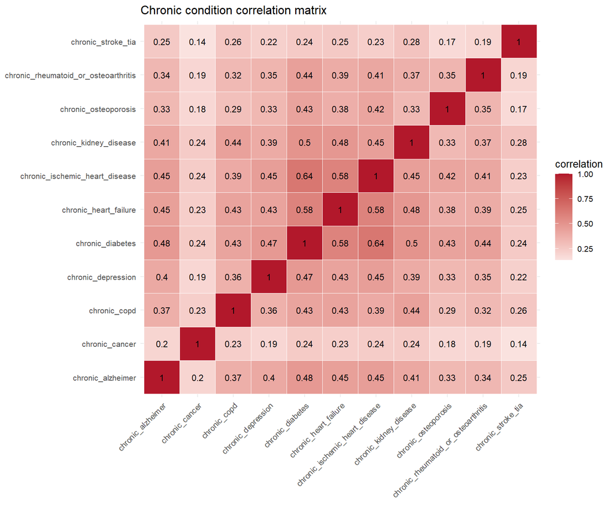

```r
cor_long <- cor_matrix %>%
  as.data.frame() %>%
  rownames_to_column("condition_1") %>%
  pivot_longer(-condition_1, names_to = "condition_2", values_to = "correlation")

ggplot(cor_long, aes(condition_1, condition_2, fill = correlation)) +
  geom_tile(color = "white") +
  geom_text(aes(label = round(correlation, 2)), size = 3) +
  scale_fill_gradient2(low = "#2166AC", mid = "white", high = "#B2182B", midpoint = 0) +
  theme_minimal(base_size = 10) +
  theme(axis.text.x = element_text(angle = 45, hjust = 1), axis.title = element_blank()) +
  labs(title = "Chronic condition correlation matrix")
```

### Most common pairwise combinations

Two different rankings, because they answer different questions: **raw co-occurrence count** (how many beneficiaries have both — naturally dominated by whichever conditions are individually most common) vs. **correlation strength** (how much more often they occur together than each condition’s base rate alone would predict).

```r
condition_pairs <- combn(condition_cols, 2, function(pair) {
  tibble(
    condition_1 = pair[1],
    condition_2 = pair[2],
    n_both = sum(bene_conditions_ever[[pair[1]]] & bene_conditions_ever[[pair[2]]]),
    correlation = cor_matrix[pair[1], pair[2]]
  )
}, simplify = FALSE) %>% bind_rows()

condition_pairs %>% arrange(desc(n_both)) %>% head(10) %>%
  knitr::kable(digits = 3, format.args = list(big.mark = ","),
               caption = "Top 10 condition pairs by raw co-occurrence count")
```

Top 10 condition pairs by raw co-occurrence count

| condition_1 | condition_2 | n_both | correlation |
| --- | --- | --- | --- |
| chronic_diabetes | chronic_ischemic_heart_disease | 58,392 | 0.635 |
| chronic_heart_failure | chronic_ischemic_heart_disease | 53,898 | 0.580 |
| chronic_heart_failure | chronic_diabetes | 49,618 | 0.581 |
| chronic_depression | chronic_ischemic_heart_disease | 42,601 | 0.452 |
| chronic_alzheimer | chronic_ischemic_heart_disease | 41,657 | 0.453 |
| chronic_depression | chronic_diabetes | 39,770 | 0.475 |
| chronic_alzheimer | chronic_diabetes | 38,975 | 0.477 |
| chronic_ischemic_heart_disease | chronic_osteoporosis | 38,274 | 0.420 |
| chronic_heart_failure | chronic_depression | 36,570 | 0.429 |
| chronic_alzheimer | chronic_heart_failure | 36,270 | 0.446 |

```r
condition_pairs %>% arrange(desc(correlation)) %>% head(10) %>%
  knitr::kable(digits = 3, format.args = list(big.mark = ","),
               caption = "Top 10 condition pairs by correlation strength")
```

Top 10 condition pairs by correlation strength

| condition_1 | condition_2 | n_both | correlation |
| --- | --- | --- | --- |
| chronic_diabetes | chronic_ischemic_heart_disease | 58,392 | 0.635 |
| chronic_heart_failure | chronic_diabetes | 49,618 | 0.581 |
| chronic_heart_failure | chronic_ischemic_heart_disease | 53,898 | 0.580 |
| chronic_kidney_disease | chronic_diabetes | 34,414 | 0.502 |
| chronic_heart_failure | chronic_kidney_disease | 32,468 | 0.485 |
| chronic_alzheimer | chronic_diabetes | 38,975 | 0.477 |
| chronic_depression | chronic_diabetes | 39,770 | 0.475 |
| chronic_alzheimer | chronic_ischemic_heart_disease | 41,657 | 0.453 |
| chronic_depression | chronic_ischemic_heart_disease | 42,601 | 0.452 |
| chronic_kidney_disease | chronic_ischemic_heart_disease | 35,700 | 0.450 |

Worth flagging: CMS’s own FAQ says this exact kind of multivariate relationship is what disclosure-limitation synthesis distorts most — *“much of the interdependence and co-variation among variables have been altered… univariate and multivariate statistics, such as conditional correlations and regression coefficients, would not be reliable.”* Treat these pairs as a demonstration of the method, not as real clinical comorbidity patterns (see Section 14 for the same caveat applied to dollar amounts).

## 13. Claim Costs by Chronic Condition

Joining Inpatient, Outpatient, and PDE against the ever-diagnosed condition flags from Section 12. A beneficiary with 3 conditions contributes their claims to all 3 disease rows below — that’s deliberate (a claim from a multi-morbid beneficiary genuinely belongs to every condition they carry), but it means claims are double- or triple-counted across condition rows, and the per-disease numbers are not independent samples of each other.

```r
condition_flags_long <- bene_conditions_ever %>%
  pivot_longer(all_of(condition_cols), names_to = "condition", values_to = "has_condition") %>%
  filter(has_condition) %>%
  select(beneficiary_id, condition)

cat("Beneficiary x condition rows (TRUE only):", nrow(condition_flags_long), "\n")
```

```
## Beneficiary x condition rows (TRUE only): 464586
```

```r
cost_ip <- condition_flags_long %>%
  inner_join(inpatient_clean %>% select(beneficiary_id, medicare_payment_amt),
             by = "beneficiary_id", relationship = "many-to-many") %>%
  group_by(condition) %>%
  summarise(avg_inpatient_claim_amt = mean(medicare_payment_amt, na.rm = TRUE),
            median_inpatient_claim_amt = median(medicare_payment_amt, na.rm = TRUE),
            n_inpatient_claims = n(), .groups = "drop")

cost_op <- condition_flags_long %>%
  inner_join(outpatient_clean %>% select(beneficiary_id, medicare_payment_amt),
             by = "beneficiary_id", relationship = "many-to-many") %>%
  group_by(condition) %>%
  summarise(avg_outpatient_claim_amt = mean(medicare_payment_amt, na.rm = TRUE),
            median_outpatient_claim_amt = median(medicare_payment_amt, na.rm = TRUE),
            n_outpatient_claims = n(), .groups = "drop")
```

PDE is 5.6M rows, and joining it fans out further still (a beneficiary’s prescriptions × however many conditions they carry), so this one uses `data.table` the same way Carrier Claims did in Section 7, to keep it fast and light on memory:

```r
cost_pde <- merge(
  as.data.table(condition_flags_long),
  as.data.table(pde_clean)[, .(beneficiary_id, gross_drug_cost_amt)],
  by = "beneficiary_id", allow.cartesian = TRUE
)[, .(avg_prescription_cost = mean(gross_drug_cost_amt, na.rm = TRUE),
      median_prescription_cost = median(gross_drug_cost_amt, na.rm = TRUE),
      n_prescriptions = .N), by = condition] %>%
  as_tibble()
```

```r
cost_by_disease <- cost_ip %>%
  full_join(cost_op, by = "condition") %>%
  full_join(cost_pde, by = "condition") %>%
  arrange(desc(avg_inpatient_claim_amt))

cost_by_disease %>%
  knitr::kable(digits = 2, format.args = list(big.mark = ","),
               caption = "Average & median claim amount by chronic condition (IP/OP: medicare_payment_amt; PDE: gross_drug_cost_amt)")
```

Average & median claim amount by chronic condition (IP/OP: medicare_payment_amt; PDE: gross_drug_cost_amt)

| condition | avg_inpatient_claim_amt | median_inpatient_claim_amt | n_inpatient_claims | avg_outpatient_claim_amt | median_outpatient_claim_amt | n_outpatient_claims | avg_prescription_cost | median_prescription_cost | n_prescriptions |
| --- | --- | --- | --- | --- | --- | --- | --- | --- | --- |
| chronic_kidney_disease | 9,820.57 | 7,000 | 50,483 | 328.58 | 80 | 459,508 | 65.82 | 20 | 2,395,525 |
| chronic_cancer | 9,795.80 | 7,000 | 20,335 | 310.10 | 80 | 188,223 | 63.48 | 20 | 816,823 |
| chronic_stroke_tia | 9,748.16 | 7,000 | 20,101 | 350.11 | 80 | 148,338 | 64.79 | 20 | 746,609 |
| chronic_heart_failure | 9,602.56 | 7,000 | 59,254 | 298.19 | 80 | 631,788 | 64.25 | 20 | 3,470,315 |
| chronic_ischemic_heart_disease | 9,593.69 | 7,000 | 63,797 | 289.97 | 80 | 726,245 | 63.76 | 20 | 4,020,903 |
| chronic_diabetes | 9,549.87 | 7,000 | 61,091 | 293.75 | 80 | 681,981 | 64.50 | 20 | 3,738,875 |
| chronic_rheumatoid_or_osteoarthritis | 9,520.36 | 7,000 | 38,017 | 280.86 | 80 | 406,796 | 64.80 | 20 | 2,088,753 |
| chronic_copd | 9,490.07 | 7,000 | 44,335 | 317.81 | 80 | 383,730 | 66.06 | 20 | 2,013,062 |
| chronic_osteoporosis | 9,479.04 | 7,000 | 40,688 | 285.94 | 80 | 460,202 | 64.35 | 20 | 2,423,174 |
| chronic_alzheimer | 9,442.26 | 7,000 | 49,905 | 299.46 | 80 | 510,502 | 65.48 | 20 | 2,818,960 |
| chronic_depression | 9,405.60 | 7,000 | 49,108 | 292.48 | 80 | 531,262 | 66.43 | 20 | 3,032,021 |

## 14. Reconciling Beneficiary Annual Amounts Against Claims

Do `annual_medicare_reimb_ip` / `annual_beneficiary_resp_ip` / `annual_primary_payer_reimb_ip` (and the OP equivalents) in the Beneficiary file equal what you get by summing the matching claim-level amounts for that beneficiary-year? The Codebook’s **Appendix 2 (“List of Reimbursement Variables”)** spells out CMS’s exact derivation formulas, so this check uses those instead of a naive `sum(medicare_payment_amt)`:

| Beneficiary variable | CMS’s stated derivation (Codebook Appendix 2) |
| --- | --- |
| `annual_medicare_reimb_ip` | `medicare_payment_amt + utilization_day_count * pass_through_per_diem_amt` |
| `annual_beneficiary_resp_ip` | `beneficiary_deductible_amt + beneficiary_part_a_coinsurance_amt + beneficiary_blood_deductible_amt` |
| `annual_primary_payer_reimb_ip` | `primary_payer_paid_amt` |
| `annual_medicare_reimb_op` | `medicare_payment_amt` |
| `annual_beneficiary_resp_op` | `beneficiary_blood_deductible_amt + beneficiary_part_b_deductible_amt + beneficiary_part_b_coinsurance_amt` |
| `annual_primary_payer_reimb_op` | `primary_payer_paid_amt` |

(Carrier’s equivalents are also in Appendix 2, but conditional on `LINE_PRCSG_IND_CD` — a per-line processing-indicator code dropped during the Carrier collapse in Section 7. Reconciling Carrier would mean re-deriving it from the raw files, which is out of scope here — matching what was actually asked: Inpatient and Outpatient only.)

Claims are assigned to a calendar year using `claim_end_date` (raw `CLM_THRU_DT`), per the DUG’s own footnote to Table 1: *“Year is determined by the claim through date.”*

```r
ip_by_bene_year <- inpatient_clean %>%
  mutate(claim_year = year(claim_end_date)) %>%
  group_by(beneficiary_id, reference_year = claim_year) %>%
  summarise(
    claims_medicare_ip = sum(medicare_payment_amt + utilization_day_count * pass_through_per_diem_amt, na.rm = TRUE),
    claims_benres_ip = sum(beneficiary_deductible_amt + beneficiary_part_a_coinsurance_amt + beneficiary_blood_deductible_amt, na.rm = TRUE),
    claims_pppymt_ip = sum(primary_payer_paid_amt, na.rm = TRUE),
    .groups = "drop"
  )

op_by_bene_year <- outpatient_clean %>%
  mutate(claim_year = year(claim_end_date)) %>%
  group_by(beneficiary_id, reference_year = claim_year) %>%
  summarise(
    claims_medicare_op = sum(medicare_payment_amt, na.rm = TRUE),
    claims_benres_op = sum(beneficiary_blood_deductible_amt + beneficiary_part_b_deductible_amt + beneficiary_part_b_coinsurance_amt, na.rm = TRUE),
    claims_pppymt_op = sum(primary_payer_paid_amt, na.rm = TRUE),
    .groups = "drop"
  )

reconcile <- beneficiary_all %>%
  select(beneficiary_id, reference_year,
         annual_medicare_reimb_ip, annual_beneficiary_resp_ip, annual_primary_payer_reimb_ip,
         annual_medicare_reimb_op, annual_beneficiary_resp_op, annual_primary_payer_reimb_op) %>%
  left_join(ip_by_bene_year, by = c("beneficiary_id", "reference_year")) %>%
  left_join(op_by_bene_year, by = c("beneficiary_id", "reference_year")) %>%
  mutate(across(starts_with("claims_"), ~ replace_na(.x, 0)))
```

```r
reconcile %>%
  summarise(
    ip_medicare_match_pct = round(mean(abs(annual_medicare_reimb_ip - claims_medicare_ip) < 0.01) * 100, 1),
    ip_benres_match_pct = round(mean(abs(annual_beneficiary_resp_ip - claims_benres_ip) < 0.01) * 100, 1),
    ip_pppymt_match_pct = round(mean(abs(annual_primary_payer_reimb_ip - claims_pppymt_ip) < 0.01) * 100, 1),
    op_medicare_match_pct = round(mean(abs(annual_medicare_reimb_op - claims_medicare_op) < 0.01) * 100, 1),
    op_benres_match_pct = round(mean(abs(annual_beneficiary_resp_op - claims_benres_op) < 0.01) * 100, 1),
    op_pppymt_match_pct = round(mean(abs(annual_primary_payer_reimb_op - claims_pppymt_op) < 0.01) * 100, 1)
  ) %>%
  pivot_longer(everything(), names_to = "check", values_to = "pct_exact_match") %>%
  knitr::kable(caption = "% of beneficiary-years where the annual amount exactly matches the claims-derived total")
```

% of beneficiary-years where the annual amount exactly matches the claims-derived total

| check | pct_exact_match |
| --- | --- |
| ip_medicare_match_pct | 100 |
| ip_benres_match_pct | 100 |
| ip_pppymt_match_pct | 100 |
| op_medicare_match_pct | 100 |
| op_benres_match_pct | 100 |
| op_pppymt_match_pct | 100 |

```r
reconcile %>%
  summarise(
    total_annual_medicare_ip = sum(annual_medicare_reimb_ip),
    total_claims_medicare_ip = sum(claims_medicare_ip),
    total_annual_medicare_op = sum(annual_medicare_reimb_op),
    total_claims_medicare_op = sum(claims_medicare_op)
  ) %>%
  knitr::kable(format.args = list(big.mark = ","), caption = "Portfolio-level totals: annual (beneficiary file) vs. claims-derived")
```

Portfolio-level totals: annual (beneficiary file) vs. claims-derived

| total_annual_medicare_ip | total_claims_medicare_ip | total_annual_medicare_op | total_claims_medicare_op |
| --- | --- | --- | --- |
| 648,456,860 | 648,456,860 | 209,292,350 | 209,292,350 |

### Why they match — a finding worth flagging

**Going in, the expectation (based on the DUG’s general synthesis methodology) was that these *wouldn’t* reconcile.** Section 6 (“Methodology and Limitation”) of the Data User’s Guide describes each synthetic beneficiary starting from a real “seed,” with *“the claims from the seed beneficiary… replaced with claims from other donor beneficiary claims sets”* — donor substitution that would normally decouple a beneficiary’s summary totals from whatever claims ended up attached to their synthetic ID.

**The actual result above is the opposite: a 100% exact match**, at both the beneficiary-year level (all six checks) and the portfolio level (`total_annual_medicare_ip` = `total_claims_medicare_ip` = $648,456,860; `total_annual_medicare_op` = `total_claims_medicare_op` = $209,292,350, to the dollar). The reason is in the Codebook’s **Appendix 2 (“List of Reimbursement Variables”)** used to build the formulas in the table above: it defines `MEDREIMB_IP`, `BENRES_IP`, `PPPYMT_IP`, etc. as literal sums *over the claim-level fields*, not as an independently-donor-sourced figure. That strongly suggests CMS computed these nine annual columns *after* finalizing the synthetic claims for a given release, as a rollup of those exact synthetic claims — so they’re internally consistent with this extract’s Inpatient/Outpatient files by construction, not by coincidence.

This is a narrower guarantee than it might look, though: the donor substitution the DUG describes still applies to *other* Beneficiary fields — demographics, and especially the chronic-condition flags behind Sections 12–13 — which aren’t derived from the claims files the same way and carry no such reconciliation guarantee. CMS’s FAQ underscores that distinction directly: *“much of the interdependence and co-variation among variables have been altered… conditional correlations… would not be reliable.”* Read as: the dollar totals tie out; the relationships between conditions, demographics, and cost don’t necessarily.

Sources: CMS *DE-SynPUF Data User’s Guide*, Section 6 (“Methodology and Limitation”), `Docs/synpuf_dug.pdf`; CMS *DE-SynPUF Codebook*, Appendix 2 (“List of Reimbursement Variables”), `Docs/de10_codebook.pdf`; CMS *DE-SynPUF FAQ*, `Docs/de10_faq.pdf`.

## 15. Next steps

- `total_claim_amt` (IP/OP/Carrier) and `total_annual_amt` (Beneficiary) sum Medicare-paid + primary-payer-paid + beneficiary liability. For IP/OP that’s an exact reconstruction of the claim’s billed components; for Carrier it’s a claim-level sum of already-summed line-level components, so it inherits whatever rounding CMS’s synthetic-data process introduced at the line level. `total_annual_amt` is the beneficiary-year rollup of the same three components across all three claim types (IP+OP+Carrier) — it is *not* directly comparable to a single claim’s `total_claim_amt`.
- The carrier-claims collapse (142 → 21 columns) is a real simplification, not a data-quality fix — if per-line physician or processing-indicator detail turns out to matter for a later analysis, that needs a reshape to long format instead of this claim-level summary.
- `race` and `state` are recoded per the Codebook’s own category tables; both carry the Codebook’s own disclosure-treatment caveats (race in particular is flagged as imputed/coarsened — CMS says not to draw population inferences from it).
- All four referential checks (inpatient/outpatient/carrier/PDE against the beneficiary file) came back clean above; worth re-running if a different sample or year range is pulled later.
- If sharing this notebook, note that although the data is fully synthetic, it’s still meant to structurally resemble real CMS PUFs — treat it as a stand-in for real claims data, not for external distribution as “real” Medicare statistics.
- Section 14’s reconciliation came back a **perfect 100% match** for Inpatient and Outpatient — the opposite of what the DUG’s general donor-substitution methodology predicted going in, and traceable instead to the Codebook’s Appendix 2 defining these annual fields as literal sums over this release’s claims. That guarantee is specific to the nine annual reimbursement columns, though — it says nothing about the chronic condition flags (Sections 12–13) or demographics, which follow the more general donor-substitution path the DUG describes and carry no such reconciliation guarantee. Treat the condition correlations and cost-by-disease breakdown as a demonstration of the pipeline, not as clinical or actuarial fact.
- `cost_by_disease` (Section 13) double/triple-counts claims across comorbid conditions by design (see that section) — don’t sum the `n_*_claims` column across rows expecting it to equal total claim counts.